# week2Project

Sergio Rosales

December 2, 2016

## **1. Loading and preprocessing the data**

Next piece of code read the data from a .csv file. Date is also Processed/transformed into a format suitable for your analysis:

```r
rutaF <- file.path(getwd(),"/activity.csv")
AMD <- read.csv(rutaF, header = TRUE, na.strings = "NA", colClasses= c("integer","Date","integer"), stringsAsFactors= FALSE)
```

## **2. What is mean total number of steps taken per day?**

### 2.1 Calculate the total number of steps taken per day

The total number of steps taken per day is saved in varable “TSPD”

```r
TSPD <- aggregate(steps~date,data= AMD,FUN= sum)
```

### 2.2 Make a histogram of the total number of steps taken each day

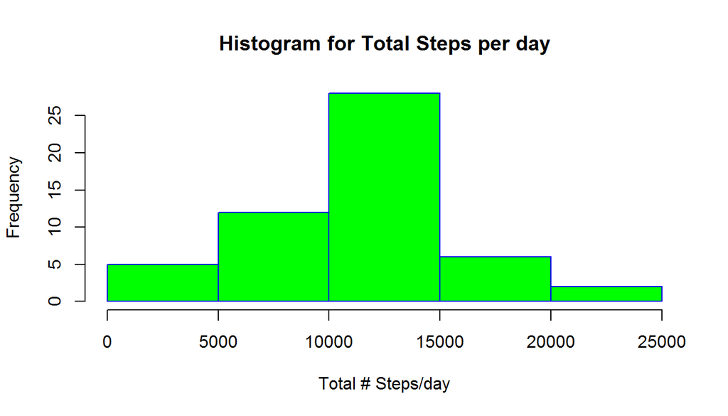

```r
with(TSPD,hist(steps,
    main= "Histogram for Total Steps per day",
    xlab= "Total # Steps/day",
    border= "blue",
    col= "green",
    breaks= 5))
```

```r
meanTSPD <- mean(TSPD$steps,na.rm = TRUE)
medianTSPD <- median(TSPD$steps,na.rm = TRUE)
```

## **3. What is the average daily activity pattern?**

### 3.1 Make a time series plot (i.e. type = “l”) of the 5-minute interval (x-axis) and the average number of steps taken, averaged across all days (y-axis)

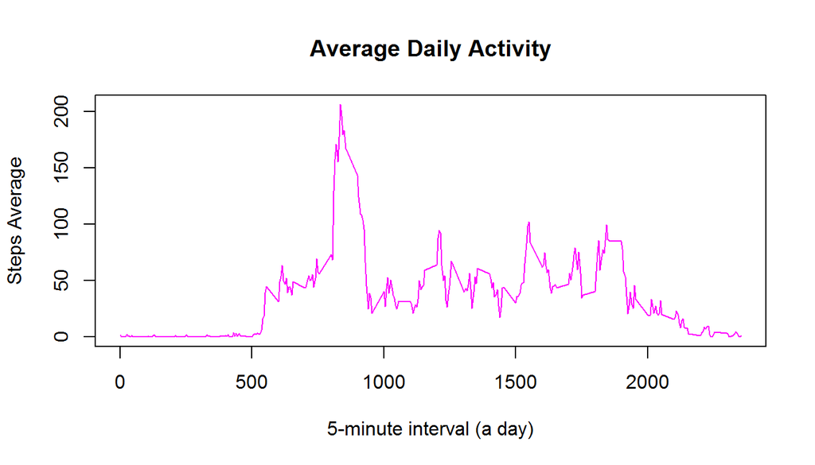

```r
ADSPI <- aggregate(steps~interval,data= AMD,FUN= mean)
with(ADSPI,plot(interval, steps,
    main= "Average Daily Activity",
    xlab= "5-minute interval (a day)",
    ylab= "Steps Average",
    col= "magenta",
    type= "l"
    ))
```

### 3.2 Which 5-minute interval, on average across all the days in the dataset, contains the maximum number of steps?

```r
MAXint <- ADSPI$interval[ADSPI$steps==max(ADSPI$steps)]
```

The 5-minute interval, on average across all the days in the dataset, that contains the maximum number of steps is 835.

## **4. Imputing missing values**

Note that there are a number of days/intervals where there are missing values (coded as NA). The presence of missing days may introduce bias into some calculations or summaries of the data.

### 4.1 Calculate and report the total number of missing values in the dataset (i.e. the total number of rows with NAs)

```r
TNNA <- nrow(AMD)-sum(complete.cases(AMD))
```

The total number of missing values in the dataset is 2304.

### 4.2 Devise a strategy for filling in all of the missing values in the dataset. The strategy uses the mean for that 5-minute interval.

The strategy is split the oroginal data set into one dataset with the “complete.cases” and another dataset with the “NA” cases. Then I replace NAs with the proper average of steps matching the interval number.

### 4.3 Create a new dataset (AMDiNA) that is equal to the original dataset but with the missing data filled in.

```r
TNNA <- nrow(AMD)-sum(complete.cases(AMD))
CCDS <- AMD[complete.cases(AMD),]
NADS <- AMD[!complete.cases(AMD),]
NADS$steps <- ADSPI[ADSPI$interval %in% NADS$interval,2]
AMDiNA <- rbind(CCDS,NADS)
AMDiNA <- AMDiNA[order(as.integer(row.names(AMDiNA))),]
```

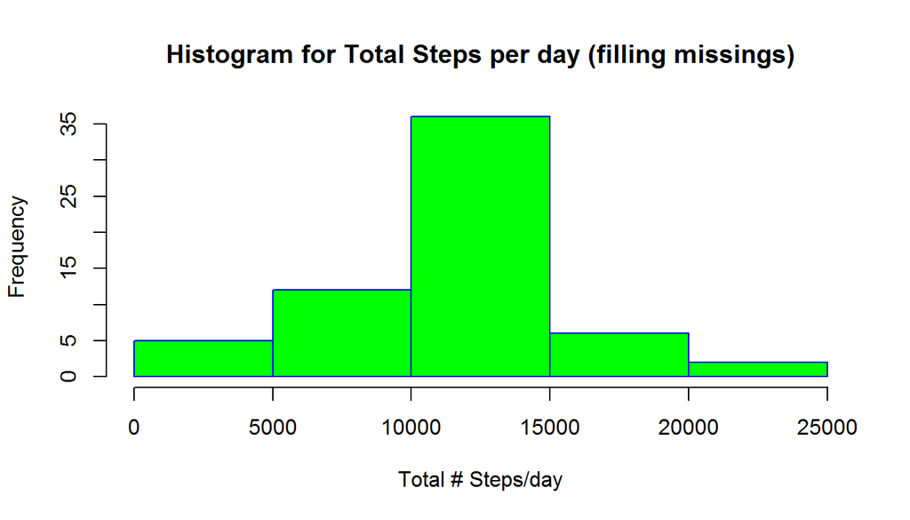

```r
TSPD2 <- aggregate(steps~date,data= AMDiNA,FUN= sum)
with(TSPD2,hist(steps,
    main= "Histogram for Total Steps per day (filling missings)",
    xlab= "Total # Steps/day",
    border= "blue",
    col= "green",
    breaks= 5))
```

```r
meanTSPD2 <- mean(TSPD2$steps,na.rm = TRUE)
medianTSPD2 <- median(TSPD2$steps,na.rm = TRUE)
```

## **5. Are there differences in activity patterns between weekdays and weekends?**

For this part the weekdays() function may be of some help here. Use the dataset with the filled-in missing values for this part.

### 5.1 Create a new factor variable in the dataset with two levels - “weekday” and “weekend” indicating whether a given date is a weekday or weekend day.

```r
AMDiNA$FacWeek <- as.factor(ifelse(weekdays(AMDiNA$date) == "Sunday" | weekdays(AMDiNA$date) == "Saturday","weekend","weekday"))
```

### 5.2 Make a panel plot containing a time series plot (i.e. type = “l”) of the 5-minute interval (x-axis) and the average number of steps taken, averaged across all weekday days or weekend days (y-axis).

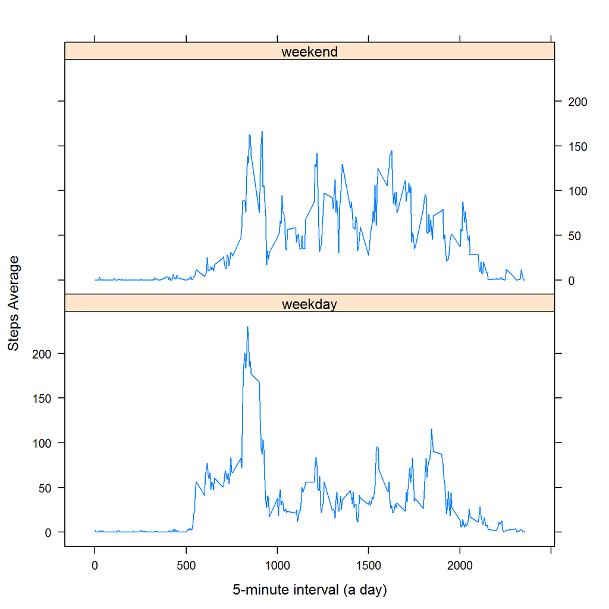

```r
ADSPINAWD <- aggregate(steps~interval,data= subset(AMDiNA,AMDiNA$FacWeek == "weekday"),FUN= mean)
ADSPINAWE <- aggregate(steps~interval,data= subset(AMDiNA,AMDiNA$FacWeek == "weekend"),FUN= mean)
ADSPINAWD$FacWeek <- "weekday"
ADSPINAWE$FacWeek <- "weekend"
ADSPINAW <- rbind(ADSPINAWD,ADSPINAWE)
library(lattice)
xyplot(steps~interval|FacWeek, data= ADSPINAW, xlab= "5-minute interval (a day)", ylab= "Steps Average", layout= c(1,2), type= "l")
```